# Results from spatial simulations

David L Miller and Mark V Bravington

```r
library(ggplot2)
library(reshape2)
library(plyr)
library(viridis)
```

# Simulation setup

- No group size issues – everything is group size 1
- No issues with $\hat{g}(0)$
- Ignoring the possibility of repeat surveys

## Spatial models

- Isotropic smooths
  - Thin plate spline (`bs="tp"`)
  - Thin plate spline with shrinkage (`bs="ts"`)
  - Duchon spline (`bs="ds", m=c(1, 0.5)`)
  - Thin plate spline with rotated covariates (`bs="tp"`)
- Tensor product smooths
  - Thin plate spline (`bs="tp"`)
  - Thin plate spline with rotated covariates (`bs="tp"`)

In the rotated covariate case, the coordinates were rotated through 45$^o$ by the rotation matrix:
$$R= \begin{pmatrix}
\cos(\pi/4) & -\sin(\pi/4)\\
\sin(\pi/4) & \cos(\pi/4)
\end{pmatrix}$$

## Non-spatially explicit models

- Horvitz-Thompson
- Horvitz-Thompson stratified with 2 strata: $x\leq 0.5$ and $x>0.5$.

## True distributions

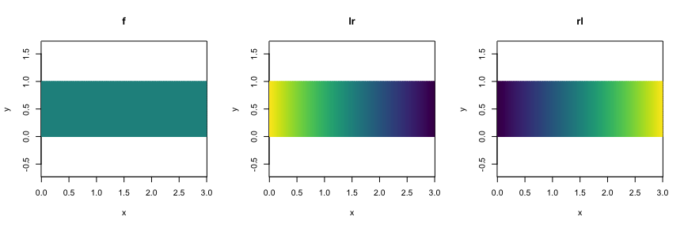

## Detectability

Detections were generated using a hazard-rate detection function with a scale parameter of 0.03 (except in the `rl_002` and `rl_001` cases, where it was set to 0.02 and 0.01, respectively) and a shape parameter of 3 (except in the `rl_002` and `rl_001` cases, where it was set to 1.5 and 1.1, respectively).

Models were fitted assuming the form of the detection function (hazard-rate) was known, as well as the truncation distance (set as simulated from).

## Designs

### Design 1 – zig-zag with straight line

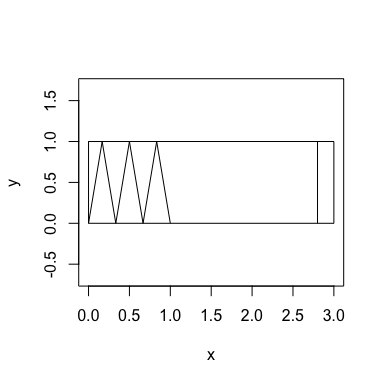

## Metrics

### Where does the truth lie in the distribution of the model?

If we know $N_\text{truth}$ then at what quantile does it lie in the distribution implied by the model, so find $\mathbb{P}[N_\text{truth} \leq \hat{N}]$. Here we assume log-normally distributed $\hat{N}$, so we can use `plnorm` in R to calculate the value we require. This summary statistic gives some idea of both bias and variance.

If the distribution of the statistic is skewed to either end then we can infer under or over estimation of abundance. Flat distribution is good, a “dome” in the middle indicates a conservative estimate (CIs slightly too wide), which we like.

# Results

## f

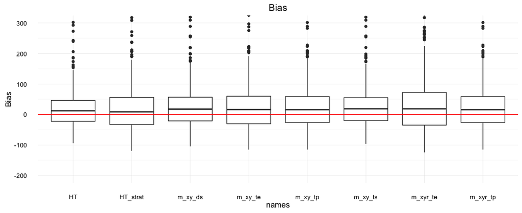

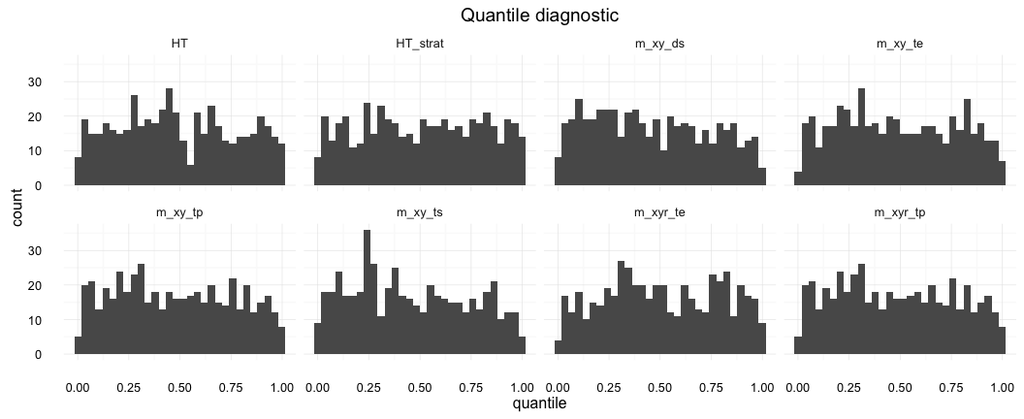

## lr

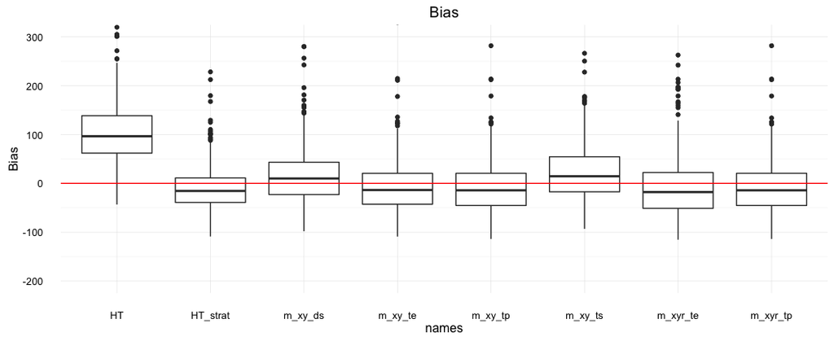

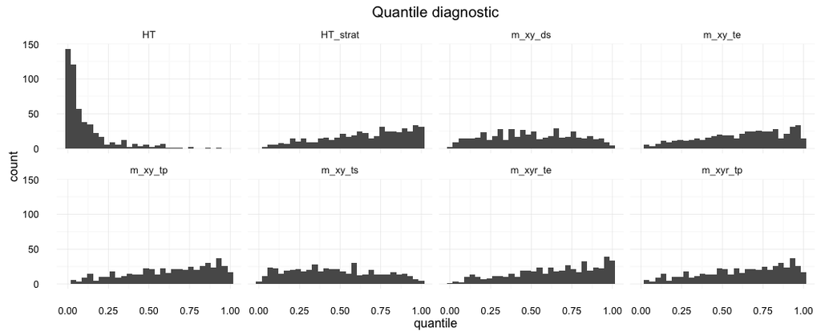

## rl

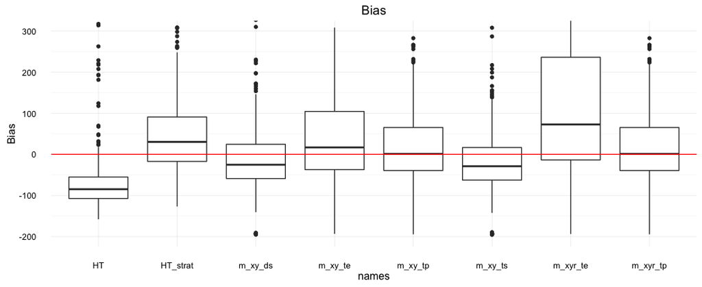

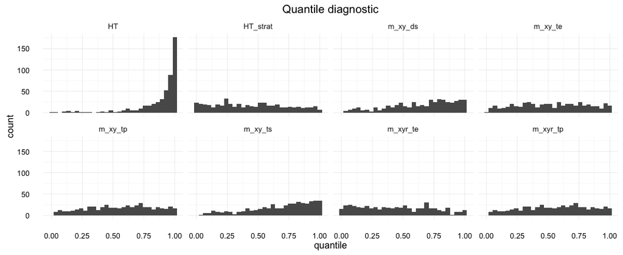

## rl_002

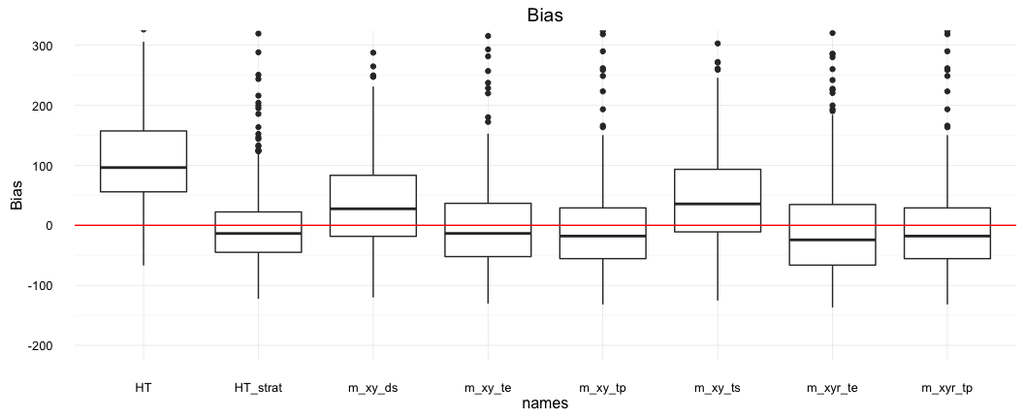

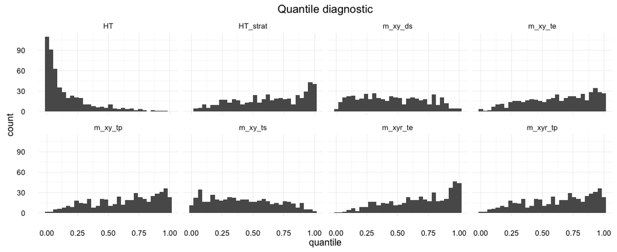

## rl_001

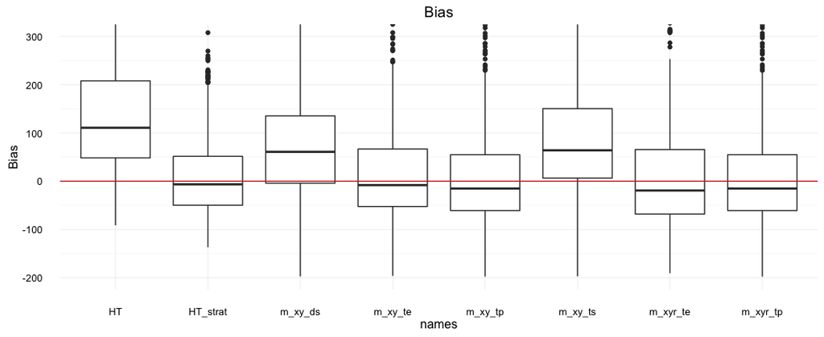

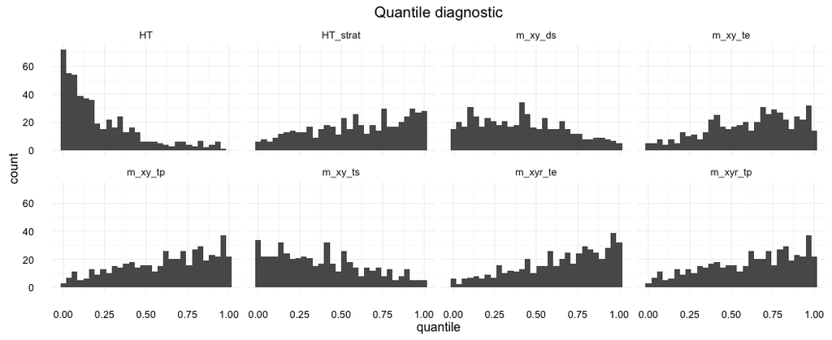

## Number of detections per simulation

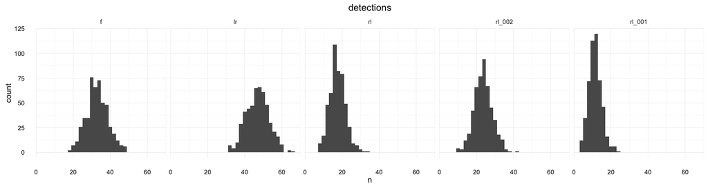